# Practical Machine Learning Course Project

by H. Chung

# Project Background

Using devices such as *Jawbone Up*, *Nike Fuelband*, and *Fitbit*, it is now possible to collect huge amounts of personal activity data inexpensively. These devices are part of the quantified self movement, or a group of enthusiasts who take measurements about themselves on a regular basis to improve their health, find behavioral patterns of themselves, or they are just tech geeks. The common activity that people do is to quantify *how much* of a particular activity they do, but *rarely quantify how well they do it*.

In this project, the goal is to use obtained data from accelerometers from the belt, forearm, arm, and dumbbell of six (6) participants. Each participant was tasked to perform barbell lifts correctly and incorrectly in five (5) different ways. Further information about the activity is found on the **Weight Lifting Exercise Dataset** in [this website](http://web.archive.org/web/20161224072740/http:/groupware.les.inf.puc-rio.br/har).

# Data Loading and Exploration

The datasets to be used for this project are as following:

- [Training Dataset](https://d396qusza40orc.cloudfront.net/predmachlearn/pml-training.csv) - *pml-training.csv*
- [Testing Dataset](https://d396qusza40orc.cloudfront.net/predmachlearn/pml-testing.csv) - *pml-testing.csv*

After downloading the csv files to be used for this project, we then load these datasets on RStudio using the code below. We also load the different packages that we will be using throughout the course of making the project.

*Note: The packages to be used should already be installed prior to loading them. If they have not yet been installed, use the code **install.packages(‘*insert package name*’)*** .

```r
# Loading Packages
library(caret)
library(rpart)
library(rpart.plot)
library(RColorBrewer)
library(rattle)
library(corrplot)
library(e1071)
library(randomForest)
library(gbm)

# Loading Data
data_train <- read.csv('pml-training.csv')
data_test <- read.csv('pml-testing.csv')
```

Once the data has been loaded, we now look into the dimensions and how it looks like.

```r
dim(data_train)
```

```
## [1] 19622   160
```

```r
dim(data_test)
```

```
## [1]  20 160
```

```r
names(data_train)
```

```
##   [1] "X"                        "user_name"
##   [3] "raw_timestamp_part_1"     "raw_timestamp_part_2"
##   [5] "cvtd_timestamp"           "new_window"
##   [7] "num_window"               "roll_belt"
##   [9] "pitch_belt"               "yaw_belt"
##  [11] "total_accel_belt"         "kurtosis_roll_belt"
##  [13] "kurtosis_picth_belt"      "kurtosis_yaw_belt"
##  [15] "skewness_roll_belt"       "skewness_roll_belt.1"
##  [17] "skewness_yaw_belt"        "max_roll_belt"
##  [19] "max_picth_belt"           "max_yaw_belt"
##  [21] "min_roll_belt"            "min_pitch_belt"
##  [23] "min_yaw_belt"             "amplitude_roll_belt"
##  [25] "amplitude_pitch_belt"     "amplitude_yaw_belt"
##  [27] "var_total_accel_belt"     "avg_roll_belt"
##  [29] "stddev_roll_belt"         "var_roll_belt"
```

[output cut: 65 more lines]

From the dimensions generated, we can see that the *training dataset has 19622 observations and 160 variables* while the *testing dataset has 20 observations and 160 variables*.

### Data Cleaning

Based from the column names shown, the first 7 variables may already be removed as they are independent and have no impact on predicting the target outcome (**classe**).

```r
data_train <- data_train[,-c(1:7)]
data_test <- data_test[,-c(1:7)]
```

The next thing that we will do is to check for missing values from the variables and remove them from our datasets.

```r
data_train <- data_train[, colSums(is.na(data_train)) == 0]
data_test <- data_test[, colSums(is.na(data_test)) == 0]

dim(data_train)
```

```
## [1] 19622    86
```

```r
dim(data_test)
```

```
## [1] 20 53
```

We can see now that we have reduced the number of variables to 86 and 53 for training and testing datasets, respectively.

### Data Preparation

```r
set.seed(1234) # so partitioning is consistent

data_separation <- createDataPartition(data_train$classe, p = 0.7, list = FALSE)
data_train <- data_train[data_separation, ]
data_validate <- data_train[-data_separation, ]

dim(data_train)
```

```
## [1] 13737    86
```

```r
dim(data_validate)
```

```
## [1] 4124   86
```

We proceed now to removing variables that have **near zero variance**.

```r
nzv <- nearZeroVar(data_train)
data_train <- data_train[, -nzv]
data_validate <- data_validate[, -nzv]

dim(data_train)
```

```
## [1] 13737    53
```

```r
dim(data_validate)
```

```
## [1] 4124   53
```

Now, we are down to 53 variables for all datasets (Train, Validate, and Test).

### Correlation Analysis

A correlation among variables is analysed before proceeding to the modeling procedures. This is to lessen the variables further by identifying variables which are highly similar (correlated) to each other.

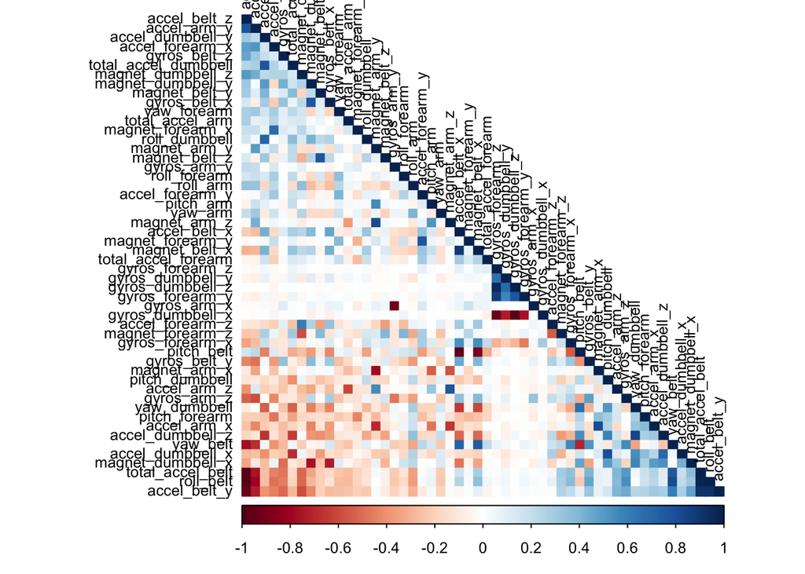

```r
corMatrix <- cor(data_train[, -53])
corrplot(corMatrix, order = "FPC", method = "color", type = "lower", tl.cex = 0.8, tl.col = rgb(0, 0, 0))
```

The correlation plot above shows which variables are highly correlated (the dark the color, the more correlated). However, in order to find out the names of these variables, we use the code below, and we set our correlation cutoff at 0.75.

```r
correlated <- findCorrelation(corMatrix, cutoff = 0.75)
names(data_train)[correlated]
```

```
##  [1] "accel_belt_z"      "roll_belt"         "accel_belt_y"
##  [4] "total_accel_belt"  "accel_dumbbell_z"  "accel_belt_x"
##  [7] "pitch_belt"        "magnet_dumbbell_x" "accel_dumbbell_y"
## [10] "magnet_dumbbell_y" "accel_arm_x"       "accel_dumbbell_x"
## [13] "accel_arm_z"       "magnet_arm_y"      "magnet_belt_z"
## [16] "accel_forearm_y"   "gyros_forearm_y"   "gyros_dumbbell_x"
## [19] "gyros_dumbbell_z"  "gyros_arm_x"
```

# Model Building

### 1. Random Forest

```r
set.seed(12345)
controlRF <- trainControl(method = 'cv', number = 3, verboseIter = FALSE)
modelfitRF <- train(classe ~., data = data_train, method = 'rf', trControl = controlRF)

modelfitRF$finalModel
```

```
##
## Call:
##  randomForest(x = x, y = y, mtry = param$mtry)
##                Type of random forest: classification
##                      Number of trees: 500
## No. of variables tried at each split: 2
##
##         OOB estimate of  error rate: 0.63%
## Confusion matrix:
##      A    B    C    D    E  class.error
## A 3904    2    0    0    0 0.0005120328
## B   15 2639    4    0    0 0.0071482318
## C    0   15 2380    1    0 0.0066777963
## D    0    0   43 2208    1 0.0195381883
## E    0    0    1    5 2519 0.0023762376
```

We then validate the model using data_validate to find out how well it performs by looking at the Accuracy.

```r
predictRF <- predict(modelfitRF, newdata = data_validate)
confMatrixRF <- confusionMatrix(predictRF, data_validate$classe)
confMatrixRF
```

```
## Confusion Matrix and Statistics
##
##           Reference
## Prediction    A    B    C    D    E
##          A 1176    0    0    0    0
##          B    0  799    0    0    0
##          C    0    0  711    0    0
##          D    0    0    0  679    0
##          E    0    0    0    0  759
##
## Overall Statistics
##
##                Accuracy : 1
##                  95% CI : (0.9991, 1)
##     No Information Rate : 0.2852
##     P-Value [Acc > NIR] : < 2.2e-16
##
##                   Kappa : 1
##
##  Mcnemar's Test P-Value : NA
##
## Statistics by Class:
##
##                      Class: A Class: B Class: C Class: D Class: E
## Sensitivity            1.0000   1.0000   1.0000   1.0000    1.000
## Specificity            1.0000   1.0000   1.0000   1.0000    1.000
## Pos Pred Value         1.0000   1.0000   1.0000   1.0000    1.000
## Neg Pred Value         1.0000   1.0000   1.0000   1.0000    1.000
## Prevalence             0.2852   0.1937   0.1724   0.1646    0.184
## Detection Rate         0.2852   0.1937   0.1724   0.1646    0.184
## Detection Prevalence   0.2852   0.1937   0.1724   0.1646    0.184
## Balanced Accuracy      1.0000   1.0000   1.0000   1.0000    1.000
```

### 2. Gradient Boosting Method

```r
set.seed(12345)
controlGBM <- trainControl(method = "repeatedcv", number = 5, repeats = 1)
modelfitGBM  <- train(classe ~ ., data = data_train, method = "gbm", trControl = controlGBM, verbose = FALSE)
print(modelfitGBM)
```

```
## Stochastic Gradient Boosting
##
## 13737 samples
##    52 predictor
##     5 classes: 'A', 'B', 'C', 'D', 'E'
##
## No pre-processing
## Resampling: Cross-Validated (5 fold, repeated 1 times)
## Summary of sample sizes: 10990, 10991, 10989, 10990, 10988
## Resampling results across tuning parameters:
##
##   interaction.depth  n.trees  Accuracy   Kappa
##   1                   50      0.7510370  0.6845815
##   1                  100      0.8171350  0.7686429
##   1                  150      0.8533135  0.8144335
##   2                   50      0.8520032  0.8125199
##   2                  100      0.9071828  0.8825490
##   2                  150      0.9318612  0.9137796
##   3                   50      0.8950994  0.8671743
##   3                  100      0.9414709  0.9259338
##   3                  150      0.9609802  0.9506365
##
## Tuning parameter 'shrinkage' was held constant at a value of 0.1
##
## Tuning parameter 'n.minobsinnode' was held constant at a value of 10
## Accuracy was used to select the optimal model using the largest value.
## The final values used for the model were n.trees = 150,
##  interaction.depth = 3, shrinkage = 0.1 and n.minobsinnode = 10.
```

```r
modelfitGBM$finalModel
```

```
## A gradient boosted model with multinomial loss function.
## 150 iterations were performed.
## There were 52 predictors of which 52 had non-zero influence.
```

We then validate the model using data_validate to find out how well it performs by looking at the Accuracy.

```r
predictGBM <- predict(modelfitGBM, newdata = data_validate)
confMatrixGBM <- confusionMatrix(predictGBM, data_validate$classe)
confMatrixGBM
```

```
## Confusion Matrix and Statistics
##
##           Reference
## Prediction    A    B    C    D    E
##          A 1167   23    0    0    1
##          B    6  765   14    0    8
##          C    2   11  688   19    3
##          D    1    0    8  657    9
##          E    0    0    1    3  738
##
## Overall Statistics
##
##                Accuracy : 0.9736
##                  95% CI : (0.9682, 0.9782)
##     No Information Rate : 0.2852
##     P-Value [Acc > NIR] : < 2.2e-16
##
##                   Kappa : 0.9665
##
##  Mcnemar's Test P-Value : NA
##
## Statistics by Class:
##
##                      Class: A Class: B Class: C Class: D Class: E
## Sensitivity            0.9923   0.9574   0.9677   0.9676   0.9723
## Specificity            0.9919   0.9916   0.9897   0.9948   0.9988
## Pos Pred Value         0.9798   0.9647   0.9516   0.9733   0.9946
## Neg Pred Value         0.9969   0.9898   0.9932   0.9936   0.9938
## Prevalence             0.2852   0.1937   0.1724   0.1646   0.1840
## Detection Rate         0.2830   0.1855   0.1668   0.1593   0.1790
## Detection Prevalence   0.2888   0.1923   0.1753   0.1637   0.1799
## Balanced Accuracy      0.9921   0.9745   0.9787   0.9812   0.9856
```

### 3. Decision Tree Classifier

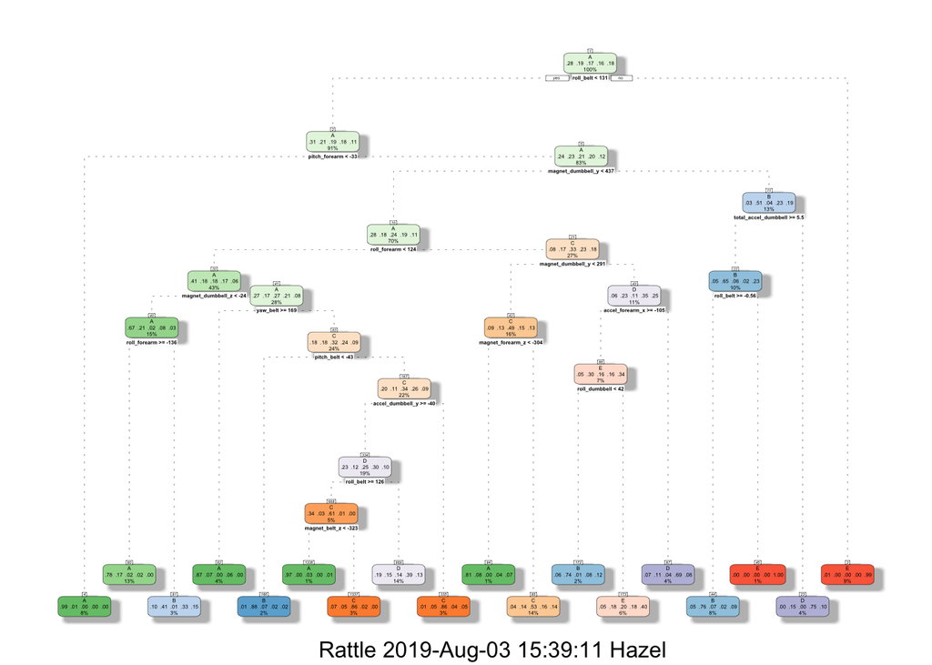

```r
set.seed(12345)
modelDT <- rpart(classe ~., data = data_train, method = 'class')
fancyRpartPlot(modelDT)
```

We then validate the model using data_validate to find out how well it performs by looking at the Accuracy.

```r
predictDT <- predict(modelDT, data_validate, type = 'class')
confMatrixDT <- confusionMatrix(predictDT, data_validate$classe)
confMatrixDT
```

```
## Confusion Matrix and Statistics
##
##           Reference
## Prediction   A   B   C   D   E
##          A 990 121  15  23   7
##          B  32 402  31  56  55
##          C  22  94 540 129  78
##          D 120 142  74 437 115
##          E  12  40  51  34 504
##
## Overall Statistics
##
##                Accuracy : 0.6967
##                  95% CI : (0.6824, 0.7107)
##     No Information Rate : 0.2852
##     P-Value [Acc > NIR] : < 2.2e-16
##
##                   Kappa : 0.6174
##
##  Mcnemar's Test P-Value : < 2.2e-16
##
## Statistics by Class:
##
##                      Class: A Class: B Class: C Class: D Class: E
## Sensitivity            0.8418  0.50313   0.7595   0.6436   0.6640
## Specificity            0.9437  0.94767   0.9054   0.8691   0.9593
## Pos Pred Value         0.8564  0.69792   0.6257   0.4921   0.7863
## Neg Pred Value         0.9373  0.88811   0.9476   0.9252   0.9268
## Prevalence             0.2852  0.19374   0.1724   0.1646   0.1840
## Detection Rate         0.2401  0.09748   0.1309   0.1060   0.1222
## Detection Prevalence   0.2803  0.13967   0.2093   0.2153   0.1554
## Balanced Accuracy      0.8928  0.72540   0.8324   0.7563   0.8117
```

# Final Model Selection and Conclusion

Using the accuracy rates we have obtained from the three (3) different predictive models (see summary below), the final model selected is the Random Forest.

1. Random Forest: 1
2. Gradient Boosting Method: 0.9736
3. Decision Trees: 0.6967

Hence, we now use it on our Test Dataset.

```r
FinalModelResult <- predict(modelfitRF, newdata = data_test)
FinalModelResult
```

```
##  [1] B A B A A E D B A A B C B A E E A B B B
## Levels: A B C D E
```